# Flanker Notebook

# **Flanker PRE DATA ANALYSIS**

N=56 (Control+Experimental) There is a 3rd undefined Condition for those that have completed this task, but have dropped out for one reason or another. note: sub190 and sub197 have no pre data (all responses were innacurate with no reaction times)

## **Data Prep**

Getting the Data ready for analysis Defaults: R uses dummy coding as it’s default. In this sample, the control Condition and the congruent condition will be the dummy variables in the analysis. So all Estimates are relative to these dummy variables

### Load Requisite R Packages

note: some of these may not actually be used. Step 1) load the necessary libraries

```r
library(ggplot2)
library(lme4)
library(languageR)
library(lmerTest) #give p-values from mixed models
library(influence.ME)
library(plyr) # magic
library(scales) #for making percents on the y-axis of graphs
```

### Read in the dataset (in current directory)

```r
Flanker_data = read.table("Flanker_R_format.csv", header = TRUE, sep = ",")
```

### Omit missing data (e.g. from practice trials)

```r
Flanker_data = na.omit(Flanker_data)
head(Flanker_data, n = 20)
```

|  | subject | session | Condition | ACC | RT | stimtype |
| --- | --- | --- | --- | --- | --- | --- |
| 1 | 5 | Pre | Experimental | 1 | 1072 | neu |
| 2 | 5 | Pre | Experimental | 1 | 453 | con |
| 3 | 5 | Pre | Experimental | 1 | 631 | neu |
| 4 | 5 | Pre | Experimental | 1 | 531 | neu |
| 5 | 5 | Pre | Experimental | 1 | 478 | con |
| 7 | 5 | Pre | Experimental | 0 | 930 | inc |
| 8 | 5 | Pre | Experimental | 1 | 436 | neu |
| 9 | 5 | Pre | Experimental | 1 | 538 | neu |
| 10 | 5 | Pre | Experimental | 1 | 503 | neu |
| 11 | 5 | Pre | Experimental | 1 | 451 | con |

[output cut: 10 more lines]

### Omit the Undefined Condition from the data and specify Condition as a factor

```r
Flanker_data <- subset(Flanker_data,Condition=="Control" | Condition=="Experimental")
Flanker_data$Condition <- factor(Flanker_data$Condition)
summary(Flanker_data)
```

```
    subject      session            Condition         ACC               RT         stimtype
 Min.   :  5.0   Post:6961   Control     :6960   Min.   :0.0000   Min.   :   0.0   0   :   3
 1st Qu.: 45.0   Pre :6842   Experimental:6843   1st Qu.:1.0000   1st Qu.: 579.0   con :4600
 Median : 98.0                                   Median :1.0000   Median : 671.0   inc :4600
 Mean   :105.5                                   Mean   :0.9132   Mean   : 690.7   neu :4600
 3rd Qu.:166.0                                   3rd Qu.:1.0000   3rd Qu.: 777.0   null:   0
 Max.   :209.0                                   Max.   :1.0000   Max.   :1974.0
```

```r
contrasts(Flanker_data$Condition)
```

```
             Experimental
Control                 0
Experimental            1
```

### Omit the Practice stimtype and specify stimtype as a factor

```r
Flanker_data <- subset(Flanker_data,stimtype=="con" | stimtype=="inc" | stimtype=="neu")
Flanker_data$stimtype <- factor(Flanker_data$stimtype)
summary(Flanker_data)
```

```
    subject      session            Condition         ACC               RT         stimtype
 Min.   :  5.0   Post:6958   Control     :6960   Min.   :0.0000   Min.   :   0.0   con:4600
 1st Qu.: 45.0   Pre :6842   Experimental:6840   1st Qu.:1.0000   1st Qu.: 579.0   inc:4600
 Median : 98.0                                   Median :1.0000   Median : 671.0   neu:4600
 Mean   :105.5                                   Mean   :0.9134   Mean   : 690.9
 3rd Qu.:166.0                                   3rd Qu.:1.0000   3rd Qu.: 777.2
 Max.   :209.0                                   Max.   :1.0000   Max.   :1974.0
```

```r
contrasts(Flanker_data$stimtype)
```

```
    inc neu
con   0   0
inc   1   0
neu   0   1
```

### Isolate the session to the first session

```r
Flanker_data_pre <- subset(Flanker_data, session=="Pre")
Flanker_data_pre$session <- factor(Flanker_data_pre$session)
summary(Flanker_data_pre)
```

```
    subject      session           Condition         ACC               RT         stimtype
 Min.   :  5.0   Pre:6842   Control     :3482   Min.   :0.0000   Min.   :   0.0   con:2280
 1st Qu.: 45.0              Experimental:3360   1st Qu.:1.0000   1st Qu.: 598.0   inc:2280
 Median : 98.0                                  Median :1.0000   Median : 689.0   neu:2282
 Mean   :105.1                                  Mean   :0.8889   Mean   : 705.6
 3rd Qu.:166.0                                  3rd Qu.:1.0000   3rd Qu.: 804.0
 Max.   :209.0                                  Max.   :1.0000   Max.   :1974.0
```

### specify subject as a factor

```r
Flanker_data_pre$subject <- as.factor(Flanker_data_pre$subject)
summary(Flanker_data_pre)
```

```
    subject     session           Condition         ACC               RT         stimtype
 209    : 240   Pre:6842   Control     :3482   Min.   :0.0000   Min.   :   0.0   con:2280
 154    : 121              Experimental:3360   1st Qu.:1.0000   1st Qu.: 598.0   inc:2280
 161    : 121                                  Median :1.0000   Median : 689.0   neu:2282
 5      : 120                                  Mean   :0.8889   Mean   : 705.6
 6      : 120                                  3rd Qu.:1.0000   3rd Qu.: 804.0
 7      : 120                                  Max.   :1.0000   Max.   :1974.0
 (Other):6000
```

## Flanker Accuracy Analysis

### Graph Accuracy Data

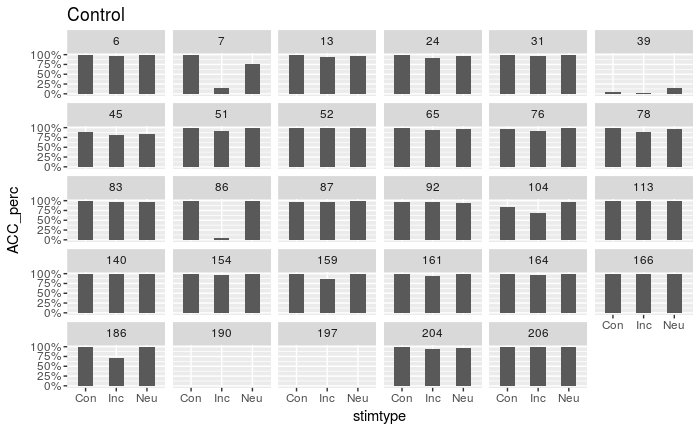

```r
#Control Condition Data
Flanker_data_pre_control <- subset(Flanker_data_pre, Condition=="Control")
#change binary data to a percent
Flanker_data_pre_control_percent <- ddply(Flanker_data_pre_control, .(stimtype, subject), summarize, ACC_perc = mean(ACC))
#Experimental Condition Data
Flanker_data_pre_experimental <- subset(Flanker_data_pre, Condition=="Experimental")
#change binary data to a percent
Flanker_data_pre_experimental_percent <- ddply(Flanker_data_pre_experimental, .(stimtype, subject), summarize, ACC_perc = mean(ACC))
ggplot(data = Flanker_data_pre_control_percent, aes( x = stimtype, y = ACC_perc)) + geom_bar(stat = "identity", width = 0.5) + facet_wrap(~subject) + scale_y_continuous(labels=percent) + scale_x_discrete(labels=c("Con","Inc","Neu")) + ggtitle("Control")
```

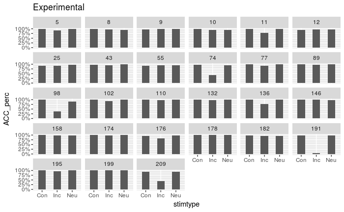

```r
ggplot(data = Flanker_data_pre_experimental_percent, aes( x = stimtype, y = ACC_perc)) + geom_bar(stat = "identity", width = 0.5) + facet_wrap(~subject) + scale_y_continuous(labels=percent) +  scale_x_discrete(labels=c("Con","Inc","Neu")) + ggtitle("Experimental")
```

**Conclusion**: Problem Subjects: sub190 sub197 sub39

Less Problematic subjects sub86 sub7 sub74 sub98 sub191

### Excluding subjects without/minimal data

```r
Flanker_data_pre <- subset(Flanker_data_pre, subject != 190 & subject != 197 & subject != 39)
summary(Flanker_data_pre)
```

```
    subject     session           Condition         ACC               RT       stimtype
 209    : 240   Pre:6482   Control     :3122   Min.   :0.0000   Min.   :   0   con:2160
 154    : 121              Experimental:3360   1st Qu.:1.0000   1st Qu.: 608   inc:2160
 161    : 121                                  Median :1.0000   Median : 693   neu:2162
 5      : 120                                  Mean   :0.9369   Mean   : 727
 6      : 120                                  3rd Qu.:1.0000   3rd Qu.: 805
 7      : 120                                  Max.   :1.0000   Max.   :1974
 (Other):5640
```

### Model Accuracy (Logit)

```r
Flanker_ACC_model<-glmer(ACC ~ Condition*stimtype + (1|subject), family=binomial, data=Flanker_data_pre, verbose=TRUE)
```

[output not shown]

```r
summary(Flanker_ACC_model)
```

```
Generalized linear mixed model fit by maximum likelihood (Laplace Approximation) ['glmerMod']
 Family: binomial  ( logit )
Formula: ACC ~ Condition * stimtype + (1 | subject)
   Data: Flanker_data_pre

     AIC      BIC   logLik deviance df.resid
  2069.2   2116.6  -1027.6   2055.2     6475

Scaled residuals:
     Min       1Q   Median       3Q      Max
-22.1581   0.0517   0.0939   0.2204   1.6662

Random effects:
 Groups  Name        Variance Std.Dev.
 subject (Intercept) 2.418    1.555
Number of obs: 6482, groups:  subject, 53

Fixed effects:
                                  Estimate Std. Error z value Pr(>|z|)
(Intercept)                         5.7899     0.4479  12.926   <2e-16 ***
ConditionExperimental              -0.6556     0.5913  -1.109   0.2675
stimtypeinc                        -3.0647     0.3168  -9.675   <2e-16 ***
stimtypeneu                        -0.7269     0.3544  -2.051   0.0402 *
ConditionExperimental:stimtypeinc   0.3012     0.4018   0.750   0.4535
ConditionExperimental:stimtypeneu   0.4547     0.4636   0.981   0.3267
---
Signif. codes:  0 ‘***’ 0.001 ‘**’ 0.01 ‘*’ 0.05 ‘.’ 0.1 ‘ ’ 1

Correlation of Fixed Effects:
                       (Intr) CndtnE stmtypnc stimtypn CndtnExprmntl:stmtypnc
CndtnExprmn            -0.747
stimtypeinc            -0.651  0.490
stimtypeneu            -0.516  0.391  0.727
CndtnExprmntl:stmtypnc  0.510 -0.616 -0.787   -0.574
CondtnExprmntl:stmtypn  0.395 -0.481 -0.556   -0.765    0.707
```

**Conclusion**: no Condition differences (as expected). Participant’s were significantly less accurate in the Incongruent condition (as expected) and the neutral condition (less expected)

## Flanker Reaction Time Analysis

### Format RT data

(subset for RTs when they are accurate, greater than 200ms, and less than 2000 ms) See how many observations are lost when we subset the data

```r
#all observations
print("All Data")
```

```
[1] "All Data"
```

```r
All_data <- length(Flanker_data_pre$RT)
summary(Flanker_data_pre)
```

```
    subject     session           Condition         ACC               RT       stimtype
 209    : 240   Pre:6482   Control     :3122   Min.   :0.0000   Min.   :   0   con:2160
 154    : 121              Experimental:3360   1st Qu.:1.0000   1st Qu.: 608   inc:2160
 161    : 121                                  Median :1.0000   Median : 693   neu:2162
 5      : 120                                  Mean   :0.9369   Mean   : 727
 6      : 120                                  3rd Qu.:1.0000   3rd Qu.: 805
 7      : 120                                  Max.   :1.0000   Max.   :1974
 (Other):5640
```

```r
#remove innacurate responses
print("Removed innacurate trials (from all data dataframe)")
```

```
[1] "Removed innacurate trials (from all data dataframe)"
```

```r
Flanker_data_pre_RT <- subset(Flanker_data_pre, ACC==1)
All_acc_data <- length(Flanker_data_pre_RT$RT)
summary(Flanker_data_pre_RT)
```

```
    subject     session           Condition         ACC          RT         stimtype
 209    : 184   Pre:6073   Control     :2947   Min.   :1   Min.   : 282.0   con:2126
 52     : 120              Experimental:3126   1st Qu.:1   1st Qu.: 611.0   inc:1837
 113    : 120                                  Median :1   Median : 692.0   neu:2110
 140    : 120                                  Mean   :1   Mean   : 726.6
 154    : 120                                  3rd Qu.:1   3rd Qu.: 796.0
 166    : 120                                  Max.   :1   Max.   :1957.0
 (Other):5289
```

```r
#remove short and long RTs
print("Removed slow and fast RTs")
```

```
[1] "Removed slow and fast RTs"
```

```r
Flanker_data_pre_RT <- subset(Flanker_data_pre_RT, RT>200 & RT<2000)
filtered_data <- length(Flanker_data_pre_RT$RT)
summary(Flanker_data_pre_RT)
```

```
    subject     session           Condition         ACC          RT         stimtype
 209    : 184   Pre:6073   Control     :2947   Min.   :1   Min.   : 282.0   con:2126
 52     : 120              Experimental:3126   1st Qu.:1   1st Qu.: 611.0   inc:1837
 113    : 120                                  Median :1   Median : 692.0   neu:2110
 140    : 120                                  Mean   :1   Mean   : 726.6
 154    : 120                                  3rd Qu.:1   3rd Qu.: 796.0
 166    : 120                                  Max.   :1   Max.   :1957.0
 (Other):5289
```

```r
print("Percentage of Data Removed")
```

```
[1] "Percentage of Data Removed"
```

```r
perc_data_rm <- (1 - (filtered_data/All_acc_data) ) * 100
perc_data_rm
```

```
[1] 0
```

**Conclusion**: No Data removed from filtering. Good to go.

### Graph RT data

Note: just doing it by stimtype since subject data appears to be in good ranges

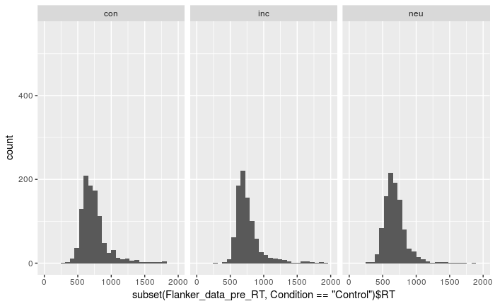

```r
#hist(subset(Flanker_data_pre_RT, Condition=="Control")$RT,ylim=c(0,1600))
#hist(subset(Flanker_data_pre_RT, Condition=="Experimental")$RT,ylim=c(0,1600))
ggplot(data = subset(Flanker_data_pre_RT, Condition=="Control"), aes(subset(Flanker_data_pre_RT, Condition=="Control")$RT)) + geom_histogram() + facet_wrap(~subset(Flanker_data_pre_RT, Condition=="Control")$stimtype) + scale_y_continuous(limits = c(0,550)) + scale_x_continuous(limits = c(0,2000))
```

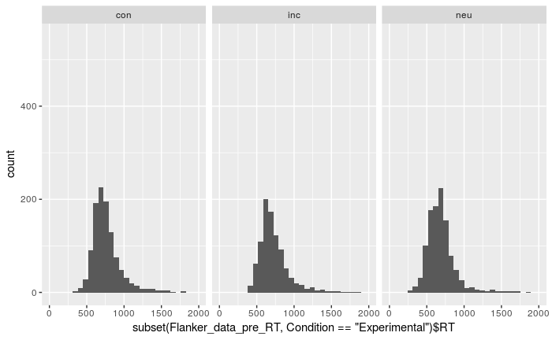

```r
ggplot(data = subset(Flanker_data_pre_RT, Condition=="Experimental"), aes(subset(Flanker_data_pre_RT, Condition=="Experimental")$RT)) + geom_histogram() + facet_wrap(~subset(Flanker_data_pre_RT, Condition=="Experimental")$stimtype) + scale_y_continuous(limits = c(0,550)) + scale_x_continuous(limits = c(0,2000))
```

**Conclusion**: data show a bit of skew, will transform to see if they look better

### Log Transform RT data

```r
Flanker_data_pre_RT$log_RT <- log(1/Flanker_data_pre_RT$RT)
```

### graph logged RT data

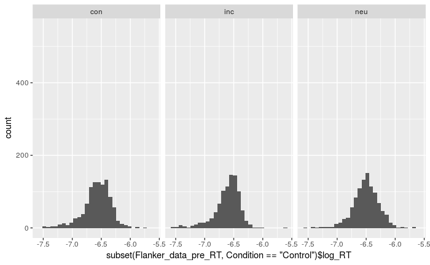

```r
#hist(subset(Flanker_data_pre_RT, Condition=="Control")$RT,ylim=c(0,1600))
#hist(subset(Flanker_data_pre_RT, Condition=="Experimental")$RT,ylim=c(0,1600))
ggplot(data = subset(Flanker_data_pre_RT, Condition=="Control"), aes(subset(Flanker_data_pre_RT, Condition=="Control")$log_RT)) + geom_histogram() + facet_wrap(~subset(Flanker_data_pre_RT, Condition=="Control")$stimtype) + scale_y_continuous(limits = c(0,550))
```

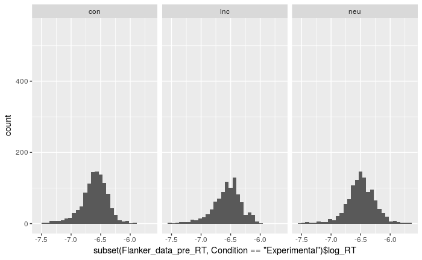

```r
ggplot(data = subset(Flanker_data_pre_RT, Condition=="Experimental"), aes(subset(Flanker_data_pre_RT, Condition=="Experimental")$log_RT)) + geom_histogram() + facet_wrap(~subset(Flanker_data_pre_RT, Condition=="Experimental")$stimtype) + scale_y_continuous(limits = c(0,550))
```

**Conclusion**: The transformed data look slightly better, I will run the model on both

### Model RT by Condition and stimtype

```r
Flanker_RT_model <- lmer(RT ~ Condition*stimtype + (1|subject), data = Flanker_data_pre_RT)
summary(Flanker_RT_model)
```

```
Linear mixed model fit by REML
t-tests use  Satterthwaite approximations to degrees of freedom ['lmerMod']
Formula: RT ~ Condition * stimtype + (1 | subject)
   Data: Flanker_data_pre_RT

REML criterion at convergence: 78043.6

Scaled residuals:
    Min      1Q  Median      3Q     Max
-4.0191 -0.5635 -0.1442  0.3431  8.9866

Random effects:
 Groups   Name        Variance Std.Dev.
 subject  (Intercept)  9895     99.47
 Residual             21711    147.35
Number of obs: 6073, groups:  subject, 53

Fixed effects:
                                  Estimate Std. Error       df t value Pr(>|t|)
(Intercept)                        685.166     20.043   55.000  34.184  < 2e-16 ***
ConditionExperimental               -2.095     28.073   54.000  -0.075 0.940771
stimtypeinc                        173.657      6.776 6020.000  25.629  < 2e-16 ***
stimtypeneu                        -21.802      6.521 6015.000  -3.343 0.000833 ***
ConditionExperimental:stimtypeinc    6.505      9.465 6019.000   0.687 0.491918
ConditionExperimental:stimtypeneu   13.780      9.063 6015.000   1.520 0.128464
---
Signif. codes:  0 ‘***’ 0.001 ‘**’ 0.01 ‘*’ 0.05 ‘.’ 0.1 ‘ ’ 1

Correlation of Fixed Effects:
                       (Intr) CndtnE stmtypnc stimtypn CndtnExprmntl:stmtypnc
CndtnExprmn            -0.714
stimtypeinc            -0.156  0.111
stimtypeneu            -0.162  0.116  0.480
CndtnExprmntl:stmtypnc  0.111 -0.154 -0.716   -0.344
CondtnExprmntl:stmtypn  0.116 -0.161 -0.346   -0.719    0.478
```

**Conclusions**: No main Condition effect or interactions (as expected), The incongruent condition is slower relative to the congruent condition (as expected). However, the neutral condition is faster than the congruent condition, which is unexpected.

### Model log RT by Condition and stimtype

```r
Flanker_log_RT_model <- lmer(log_RT ~ Condition*stimtype + (1|subject), data = Flanker_data_pre_RT)
summary(Flanker_log_RT_model)
```

```
Linear mixed model fit by REML
t-tests use  Satterthwaite approximations to degrees of freedom ['lmerMod']
Formula: log_RT ~ Condition * stimtype + (1 | subject)
   Data: Flanker_data_pre_RT

REML criterion at convergence: -3855.9

Scaled residuals:
    Min      1Q  Median      3Q     Max
-6.9900 -0.4823  0.0991  0.6069  6.4140

Random effects:
 Groups   Name        Variance Std.Dev.
 subject  (Intercept) 0.01706  0.1306
 Residual             0.02973  0.1724
Number of obs: 6073, groups:  subject, 53

Fixed effects:
                                    Estimate Std. Error         df  t value Pr(>|t|)
(Intercept)                       -6.509e+00  2.617e-02  5.400e+01 -248.702  < 2e-16 ***
ConditionExperimental              6.578e-03  3.666e-02  5.400e+01    0.179   0.8583
stimtypeinc                       -2.157e-01  7.930e-03  6.020e+03  -27.196  < 2e-16 ***
stimtypeneu                        3.089e-02  7.631e-03  6.016e+03    4.048 5.23e-05 ***
ConditionExperimental:stimtypeinc -1.607e-02  1.108e-02  6.020e+03   -1.451   0.1468
ConditionExperimental:stimtypeneu -2.058e-02  1.061e-02  6.016e+03   -1.940   0.0524 .
---
Signif. codes:  0 ‘***’ 0.001 ‘**’ 0.01 ‘*’ 0.05 ‘.’ 0.1 ‘ ’ 1

Correlation of Fixed Effects:
                       (Intr) CndtnE stmtypnc stimtypn CndtnExprmntl:stmtypnc
CndtnExprmn            -0.714
stimtypeinc            -0.140  0.100
stimtypeneu            -0.145  0.104  0.480
CndtnExprmntl:stmtypnc  0.100 -0.138 -0.716   -0.344
CondtnExprmntl:stmtypn  0.104 -0.144 -0.346   -0.719    0.478
```

**Conclusion**: Same story as the untransformed data.

## Conclusions

good: No overall Condition differences in RT and Accuracy

bad: 190,197, and 39 have almost no data. several other subjects have low accuracies. The neutral reaction times are faster than the congruent reaction times (unexpected)